# Practical Machine Learning Course Project

YMGoh

November 13, 2016

## Overview

This report describes the approach using data from accelerometers on the belt, forearm, arm, and dumbell of 6 participants to predict the manner in which they did the exercise. The data for this project has been graciously provided by Velloso et al.,(2013) at http://groupware.les.inf.puc-rio.br/har. see section on the Weight Lifting Exercise Dataset, and based on the following publication :

Velloso, E.; Bulling, A.; Gellersen, H.; Ugulino, W.; Fuks, H. “Qualitative Activity Recognition of Weight Lifting Exercises. Proceedings of 4th International Conference in Cooperation with SIGCHI (Augmented Human ’13)”. Stuttgart, Germany: ACM SIGCHI, 2013.

The dataset was obtained by asking the participants to perform barbell lifts correctly and incorrectly in 5 different ways. The five ways are, (Class A) exactly according to the specification, (Class B) throwing the elbows to the front, (Class C) lifting the dumbbell only halfway, (Class D) lowering the dumbbell only halfway and (Class E) throwing the hips to the front. Only Class A corresponds to the correct performance.According to the original authors, participants were supervised by an experienced weight lifter to make sure the execution complied to the manner they were supposed to simulate. The exercises were performed by six male participants aged between 20-28 years, with little weight lifting experience. The orignal authors also made sure that all participants could easily simulate the mistakes in a safe and controlled manner by using a relatively light dumbbell (1.25kg).

This report describes how the prediction model was built, cross validated, and then checked for their respective sample errors. These are then used to arrive at a decision to justify why a prediction approach is the best. Subsequently, the prediction model was also used to predict 20 different test cases as instructed.

## Step I : Preparing the environment and loading data

The necessary packages and libraries are first loaded

```r
library(caret); library(rattle); library(rpart); library(rpart.plot)
library(randomForest); library(repmis)
set.seed(100) # so that the results will be repeatable
```

The data was then loaded using the following code :

```r
# download data from the given URLs
pmlTrain <- "http://d396qusza40orc.cloudfront.net/predmachlearn/pml-training.csv"
pmlTest  <- "http://d396qusza40orc.cloudfront.net/predmachlearn/pml-testing.csv"

# reading and loading the datasets
training <- read.csv(url(pmlTrain))
testing  <- read.csv(url(pmlTest))

# assigning the TRAINING data to training (70%) and testing sets (the remainder)
inTrain  <- createDataPartition(training$classe, p=0.7, list=FALSE)
TrainSet <- training[inTrain, ]
TestSet  <- training[-inTrain, ]

# checking the dim attributes of the created TrainSet and TestSet
dim(TrainSet)
```

```
## [1] 13737   160
```

```r
dim(TestSet)
```

```
## [1] 5885  160
```

It is obvious that both the training set and testing set has 160 variables. Missing values (coded NA), Near Zero Variance (which will disrupt model construction), and variables pertaining to ID’s will be excluded in Step II

## Step II : Data cleaning

Removing Near Zero Variance values (using built-in function of caret), and checking dim attributes

```r
NZV <- nearZeroVar(TrainSet)
TrainSet <- TrainSet[, -NZV]
TestSet  <- TestSet[, -NZV]
dim(TrainSet)
```

```
## [1] 13737   108
```

```r
dim(TestSet)
```

```
## [1] 5885  108
```

Removing missing values in both traning and test sets, and checking dim attributes

```r
remNA    <- sapply(TrainSet, function(x) mean(is.na(x))) > 0.95
TrainSet <- TrainSet[, remNA==FALSE]
TestSet  <- TestSet[, remNA==FALSE]
dim(TrainSet)
```

```
## [1] 13737    59
```

```r
dim(TestSet)
```

```
## [1] 5885   59
```

Removing the first 5 columns associated with identification variables and checked their respective dimensionalities.

```r
TrainSet <- TrainSet[, -(1:5)]
TestSet  <- TestSet[, -(1:5)]
dim(TrainSet)
```

```
## [1] 13737    54
```

```r
dim(TestSet)
```

```
## [1] 5885   54
```

After this stage, we will be working with only 54 variables of 13737 observations in TrainSet, and 5885 observations in TestSet.

## Step III : Building prediction models

Data from step II will be used to build prediction models using firstly Decision Tree, Random Forest and finally Generalised Boosted Model.

## Step III(A) : Building model using Decision Tree

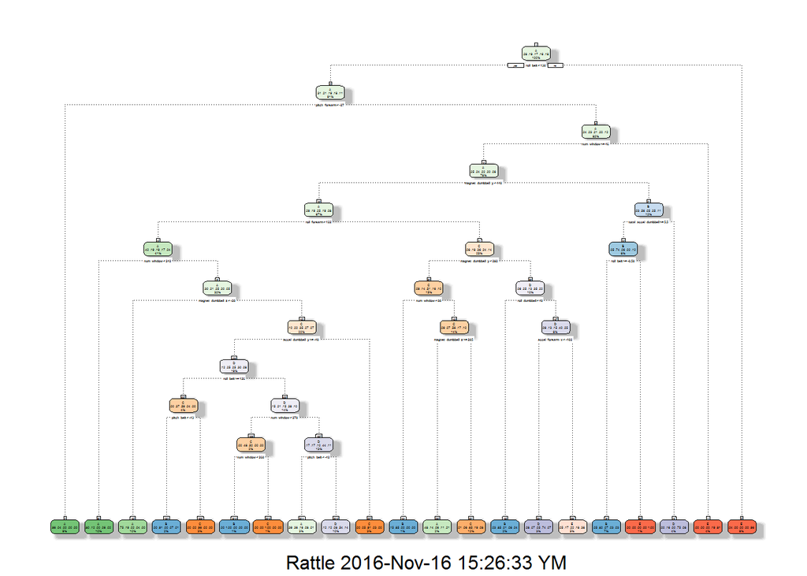

```r
set.seed(100)
dt <- rpart(classe ~ ., data=TrainSet, method="class")
fancyRpartPlot(dt)
```

Running prediction using the test set.

```r
# prediction on Test dataset
predictDT <- predict(dt, newdata=TestSet, type="class")
confDT <- confusionMatrix(predictDT, TestSet$classe)
confDT
```

```
## Confusion Matrix and Statistics
##
##           Reference
## Prediction    A    B    C    D    E
##          A 1504  305   53   96   45
##          B   43  588   35   22   19
##          C    7   71  818  134   70
##          D   75  120   55  600  128
##          E   45   55   65  112  820
##
## Overall Statistics
##
##                Accuracy : 0.7358
##                  95% CI : (0.7243, 0.747)
##     No Information Rate : 0.2845
##     P-Value [Acc > NIR] : < 2.2e-16
##
##                   Kappa : 0.6638
##  Mcnemar's Test P-Value : < 2.2e-16
##
## Statistics by Class:
##
##                      Class: A Class: B Class: C Class: D Class: E
## Sensitivity            0.8984  0.51624   0.7973   0.6224   0.7579
## Specificity            0.8815  0.97493   0.9420   0.9232   0.9423
## Pos Pred Value         0.7509  0.83168   0.7436   0.6135   0.7475
## Neg Pred Value         0.9562  0.89359   0.9565   0.9258   0.9453
## Prevalence             0.2845  0.19354   0.1743   0.1638   0.1839
## Detection Rate         0.2556  0.09992   0.1390   0.1020   0.1393
## Detection Prevalence   0.3404  0.12014   0.1869   0.1662   0.1864
## Balanced Accuracy      0.8900  0.74558   0.8696   0.7728   0.8501
```

It is clear that the model based on Decision Tree has an accuracy of 0.7358

## Step III(B):Building model using Random Forest

The classification tree was constructed using k=3 fold crossvalidation to save time. The default k=10 would potentially take much longer time.

```r
set.seed(100)
# NOTE ! Even cv=3 may take up to 15 minutes on (slower) computers !
tRF <- trainControl(method="cv", number=3, verboseIter=FALSE)
fitRF <- train(classe ~ ., data=TrainSet, method="rf",
                          trControl=tRF)
fitRF$finalModel
```

```
##
## Call:
##  randomForest(x = x, y = y, mtry = param$mtry)
##                Type of random forest: classification
##                      Number of trees: 500
## No. of variables tried at each split: 27
##
##         OOB estimate of  error rate: 0.25%
## Confusion matrix:
##      A    B    C    D    E  class.error
## A 3904    1    0    0    1 0.0005120328
## B    6 2648    3    1    0 0.0037622272
## C    0    6 2388    2    0 0.0033388982
## D    0    0    5 2245    2 0.0031083481
## E    0    1    0    6 2518 0.0027722772
```

Running prediction using the test set.

```r
predictRF <- predict(fitRF, newdata=TestSet)
confRF <- confusionMatrix(predictRF, TestSet$classe)
confRF
```

```
## Confusion Matrix and Statistics
##
##           Reference
## Prediction    A    B    C    D    E
##          A 1674    5    0    0    0
##          B    0 1134    2    0    0
##          C    0    0 1024    7    0
##          D    0    0    0  957    0
##          E    0    0    0    0 1082
##
## Overall Statistics
##
##                Accuracy : 0.9976
##                  95% CI : (0.996, 0.9987)
##     No Information Rate : 0.2845
##     P-Value [Acc > NIR] : < 2.2e-16
##
##                   Kappa : 0.997
##  Mcnemar's Test P-Value : NA
##
## Statistics by Class:
##
##                      Class: A Class: B Class: C Class: D Class: E
## Sensitivity            1.0000   0.9956   0.9981   0.9927   1.0000
## Specificity            0.9988   0.9996   0.9986   1.0000   1.0000
## Pos Pred Value         0.9970   0.9982   0.9932   1.0000   1.0000
## Neg Pred Value         1.0000   0.9989   0.9996   0.9986   1.0000
## Prevalence             0.2845   0.1935   0.1743   0.1638   0.1839
## Detection Rate         0.2845   0.1927   0.1740   0.1626   0.1839
## Detection Prevalence   0.2853   0.1930   0.1752   0.1626   0.1839
## Balanced Accuracy      0.9994   0.9976   0.9983   0.9964   1.0000
```

It is clear that the model based on Random Forest has an accuracy of 0.9976, which is the best so far !

## Step III(C):Building model using Generalised Boosted Model

```r
set.seed(100)
learnGBM <- trainControl(method = "repeatedcv", number = 5, repeats = 1)
FitGBM  <- train(classe ~ ., data=TrainSet, method = "gbm",
                    trControl = learnGBM, verbose = FALSE)
FitGBM$finalModel
```

```
## A gradient boosted model with multinomial loss function.
## 150 iterations were performed.
## There were 53 predictors of which 43 had non-zero influence.
```

Improvements in the accuracy versus the number of boosting iterations can be clearly seen in the following graph

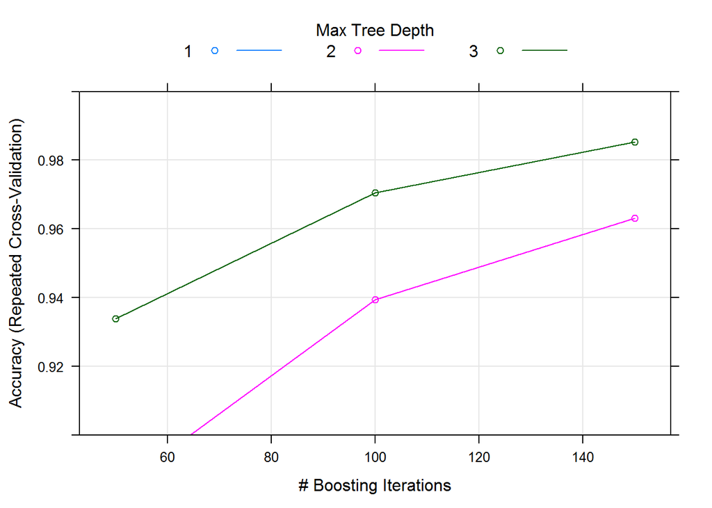

```r
plot(FitGBM, ylim=c(0.9, 1))
```

Running prediction using the test set.

```r
predictGBM <- predict(FitGBM, newdata=TestSet)
confGBM <- confusionMatrix(predictGBM, TestSet$classe)
confGBM
```

```
## Confusion Matrix and Statistics
##
##           Reference
## Prediction    A    B    C    D    E
##          A 1674   11    0    0    0
##          B    0 1112   12    5    5
##          C    0   16 1007   15    5
##          D    0    0    7  943    8
##          E    0    0    0    1 1064
##
## Overall Statistics
##
##                Accuracy : 0.9856
##                  95% CI : (0.9822, 0.9884)
##     No Information Rate : 0.2845
##     P-Value [Acc > NIR] : < 2.2e-16
##
##                   Kappa : 0.9817
##  Mcnemar's Test P-Value : NA
##
## Statistics by Class:
##
##                      Class: A Class: B Class: C Class: D Class: E
## Sensitivity            1.0000   0.9763   0.9815   0.9782   0.9834
## Specificity            0.9974   0.9954   0.9926   0.9970   0.9998
## Pos Pred Value         0.9935   0.9806   0.9655   0.9843   0.9991
## Neg Pred Value         1.0000   0.9943   0.9961   0.9957   0.9963
## Prevalence             0.2845   0.1935   0.1743   0.1638   0.1839
## Detection Rate         0.2845   0.1890   0.1711   0.1602   0.1808
## Detection Prevalence   0.2863   0.1927   0.1772   0.1628   0.1810
## Balanced Accuracy      0.9987   0.9858   0.9870   0.9876   0.9916
```

It is clear that the model based on Generalised Boosted Model has an accuracy of 0.9856. This is better than decision tree-based model, but no as good as models built using random forest.

## STEP IV : Determining the best model

Based on the above, prediction models constructed using decision tree yielded an accuracy of 73.58 %, random forest yielded 99.76 % accuracy, where as the model constructed using the Generalised Boosted Model approach had 98.56% accuracy

Thus it is clear that the Random Forest model is the best model as it has the highest accuracy, and the lowest expected out of sample error at 0.24 % only.

## STEP V : Using the best model to answer the 20 quiz questions

The codes and output are as follows :

```r
predictQuiz <- predict(fitRF, newdata=testing)
predictQuiz
```

```
##  [1] B A B A A E D B A A B C B A E E A B B B
## Levels: A B C D E
```

END OF ASSIGNMENT